# Introduction

### Implications

Fleet diversity indices are used by the MAFMC in their EAFM risk assessment to evaluate stability objectives, as well as risks to fishery resilience and maintaining equity in access to fishery resources. Instability in the commercial fleet count metric suggests lower capacity to respond to the current range of fishing opportunities. Commercial species permit revenue diversity is relatively stable (Fig. $\ref{fig:commercial-div-species-div}$) but comparisons are limited by missing historical (pre-2003) clam fishery data.

Declining recreational fleet effort diversity indicates that the party/charter boat sector continues to contract, with shoreside angling becoming a greater percentage of recreational angler trips. Stability in recreational species catch diversity has been maintained by a different set of species over time. A recent increase in Atlantic States Marine Fisheries Commission (ASMFC) and South Atlantic Fishery Management Council (SAFMC) managed species in recreational catch is helping to maintain diversity in the same range that MAFMC and New England Fishery Management Council (NEFMC) managed species supported in the 1990s. These changes in effort and species trends may necessitate new or changing management considerations to ensure effective tools and opportunities are in place to support recreational fisheries.

Production at the base of the food web is variable, but stable over time. Mid-Atlantic species composition is changing, shifting towards a higher proportion of benthic and demersal fish. Stable adult fish diversity indicates the same overall number and evenness over time, but doesn’t rule out species substitutions (e.g., warm-water species replacing cold-water species). There is evidence for long-term change in finfish trait distributions in the Mid-Atlantic.

In the MAB, both the fisheries and ecosystem are exhibiting long-term systemic shifts away from historical norms. While these changes don’t appear abrupt like one would expect during a regime shift, they do indicate a potential change in baseline conditions.

# Risks to Meeting Fishery Management Objectives

## Climate and Ecosystem Change

### Risks to managing spatially

Shifting species distributions, or (changes in spatial extent or center of distribution), alter both species and fishery interactions. In particular, shifting species distributions can affect expected management outcomes when spatial allocations and bycatch measures are based on historical fish and protected species distributions. Species availability to surveys can also change as distributions shift within or outside of survey footprints, complicating the interpretation of survey trends.

Coastwide indicators are reviewed in this section to evaluate spatial change throughout the Northeast US shelf. Indicators are identical between the Mid-Atlantic and New England reports.

#### Indicators: Fish and protected species distribution shifts

As noted in the Seafood Production Implications section, the combined center of [distribution](https://noaa-edab.github.io/catalog/species_dist.html) for 48 Northeast Shelf commercially or ecologically important fish species continues to show movement towards the northeast and generally into deeper water (Fig. $\ref{fig:species-dist}$). An analysis of recreational landings data from 2002 to 2019 found evidence of distribution shifts for several [highly migratory species](https://noaa-edab.github.io/catalog/species_dist.html), including sharks, billfish and tunas.

[Habitat model-based species richness](https://noaa-edab.github.io/catalog/habitat_diversity.html) suggests shifts of both cooler and warmer water species to the northeast. Similar patterns have been found for [marine mammals](https://noaa-edab.github.io/catalog/cetacean_dist.html), with multiple species shifting northeast between 2010 and 2017 in most seasons (Fig. $\ref{fig:protectedspp-dist-shifts}$).

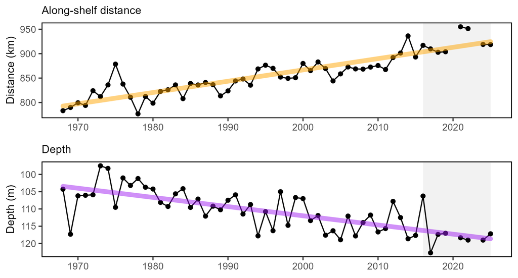

Aggregate species distribution metrics for species in the Northeast Large Marine Ecosystem: along shelf distance with increasing trend (orange), and depth with decreasing trend indicating deeper water (purple).

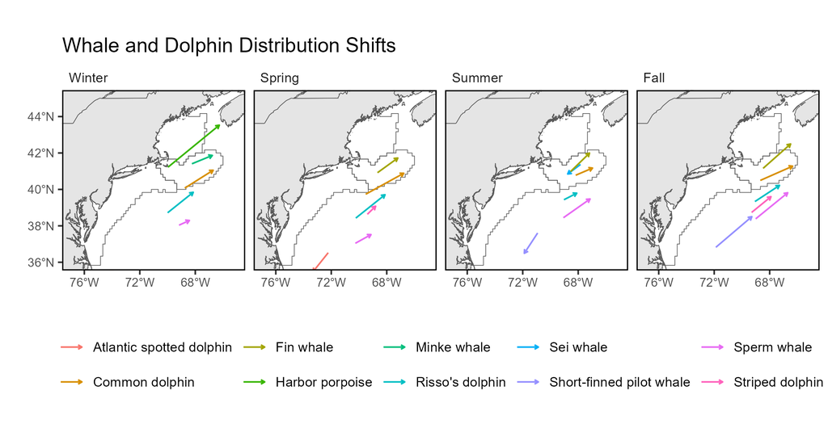

Direction and magnitude of core habitat shifts, represented by the length of the line of the seasonal weighted centroid for species with more than 70 km difference between 2010 and 2017 (tip of arrow).

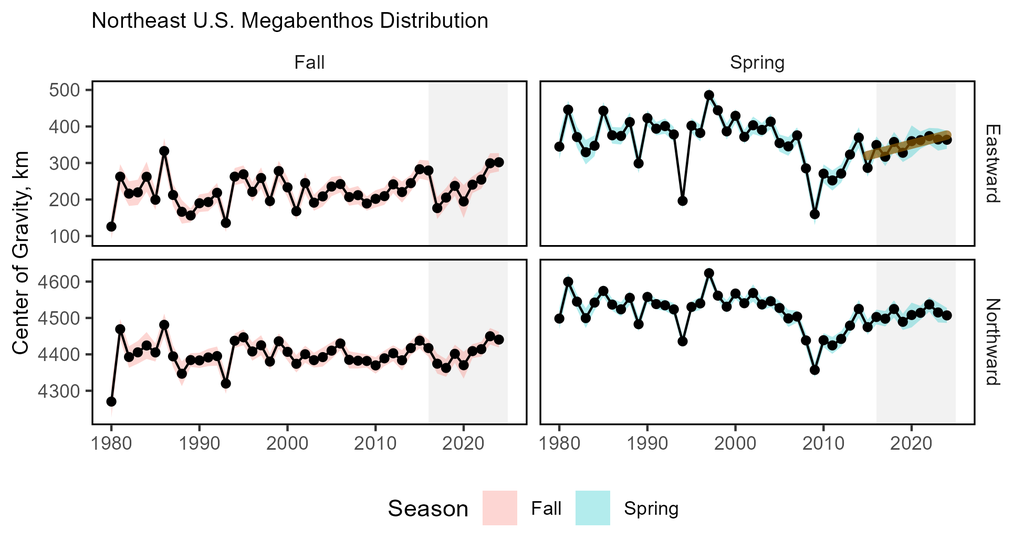

Eastward (top) and northward (bottom) shifts in the center of gravity for megabenthos species on the Northeast U.S. Shelf in fall (left) and spring (right), with recent increasing trend (orange) for spring eastward center of gravity.

#### Drivers:

Mobile populations shift distributions to maintain suitable habitat and prey fields, possibly expanding ranges if new suitable habitat exists. Changes in managed species distribution is partially related to the [distribution of forage biomass](https://noaa-edab.github.io/catalog/forage_index.html). Since 1982, the fall center of gravity of forage fish (20 species combined) has moved to the north and east (Fig. $\ref{fig:forageshifts}$). Spring forage fish center of gravity has moved northward but without an eastward trend. Some of the whale and dolphin distribution shifts (Fig. $\ref{fig:protectedspp-dist-shifts}$) are likely in response to these forage fish shifts. [Small copepods](https://noaa-edab.github.io/catalog/zooplankton_index.html#key-results-and-visualizations-4), widespread prey of many larval and juvenile fish, show a similar shift in center of gravity as forage fish, to the north and east in the fall, as well as northward in spring.

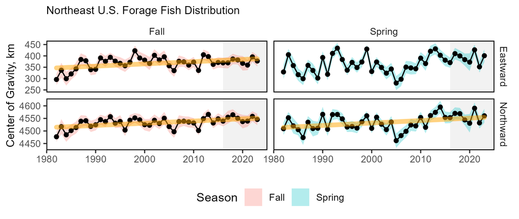

Eastward (top) and northward (bottom) shifts in the center of gravity for 20 forage fish species on the Northeast U.S. Shelf in fall (left) and spring (right), with increasing trends (orange) for fall eastward and northward and spring northward center of gravity.

In contrast, [macrobenthos](https://noaa-edab.github.io/catalog/benthos_index.html) center of gravity has shifted west and south in the spring (Fig. $\ref{fig:macrobenthosshifts}$). Macrobenthos are small bottom-dwelling invertebrates including polychaete worms, small crustaceans, bivalves (non-commercial), gastropods, nemerteans, tunicates, cnidarians, brittle stars, sea cucumbers, and sand dollars, and are prey for many managed species. [Large copepods](https://noaa-edab.github.io/catalog/zooplankton_index.html#key-results-and-visualizations-4) (including *Calanus finmarchicus*) and euphausiids do not have long-term trends in their centers of gravity (Fig. $\ref{fig:lgcopeall-cog}$) (Fig. $\ref{fig:euph-cog}$), but small copepods show shifts eastward and northward. Some targeted species distributions may shift in response to these shifts in forage, copepod, and macrobenthos distributions.

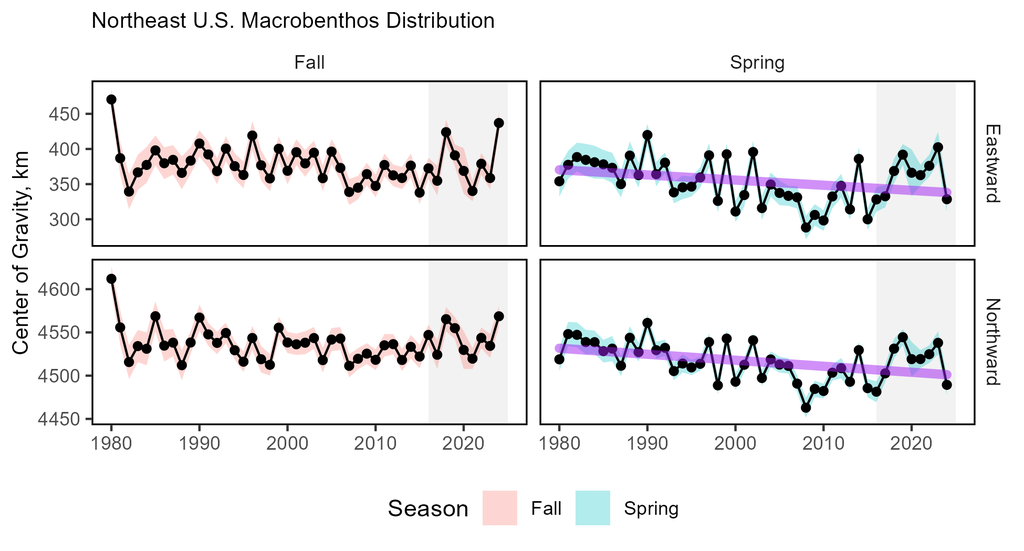

Eastward (top) and northward (bottom) shifts in the center of gravity for macrobenthos species on the Northeast U.S. Shelf in fall (left) and spring (right), with decreasing trends (purple) for spring eastward and northward center of gravity.

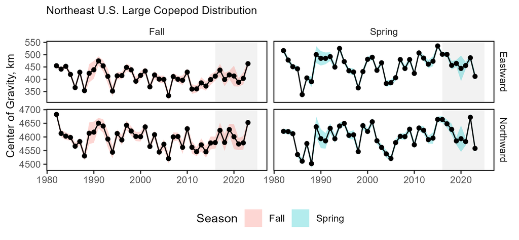

Eastward (top) and northward (bottom) shifts in the center of gravity for large copepod species on the Northeast U.S. Shelf in fall (left) and spring (right).

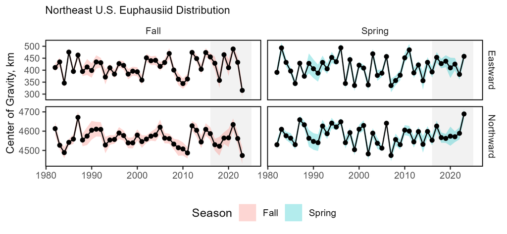

Eastward (top) and northward (bottom) shifts in the center of gravity for Euphausiid species on the Northeast U.S. Shelf in fall (left) and spring (right).

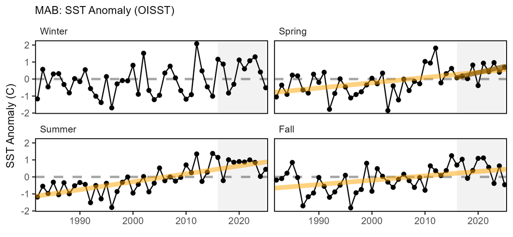

Seasonal Optimum Interpolation Sea Surface Temperature (OISST) anomaly by season for the MAB, with increasing trends (orange).

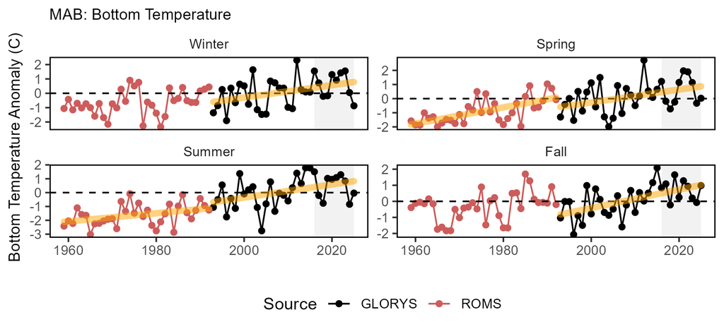

GLORYS (black) and debiased ROMS (red) seasonal bottom temperature anomaly in the MAB, with increasing trends (orange).

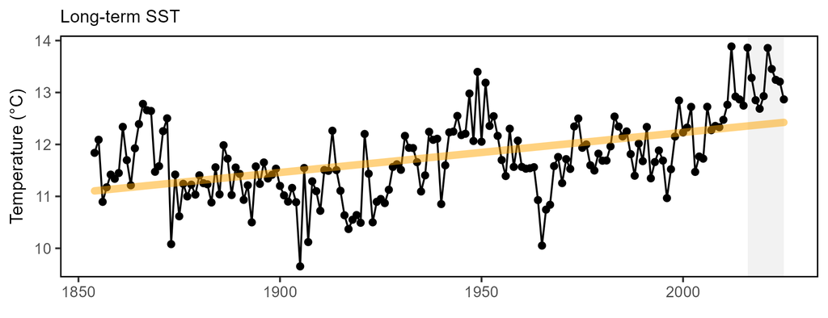

Northeast U.S. annual sea surface temperature (SST, black), with increasing trend (orange).

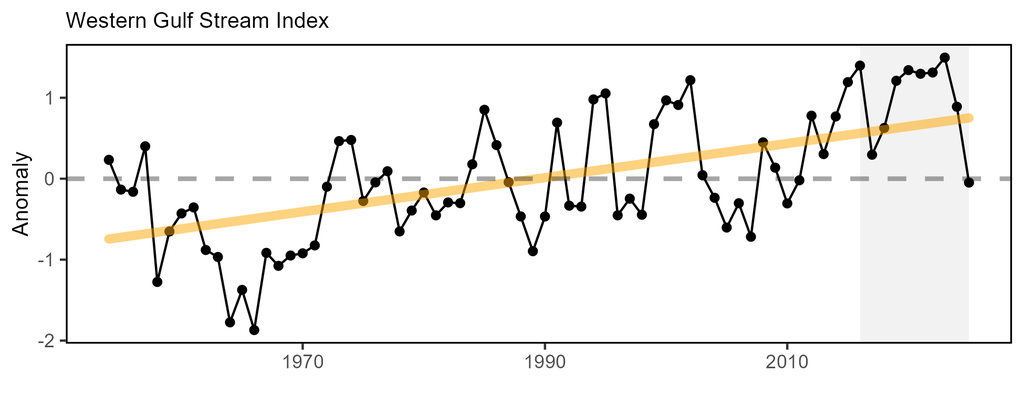

Index representing changes in the location of the western (between 64 and 55 degrees W) Gulf Stream north wall (black). Positive values represent a more northerly Gulf Stream position, with increasing trend (orange).

Changes in ocean temperature and circulation alter habitat features such as the Mid-Atlantic Bight [Cold Pool](https://noaa-edab.github.io/catalog/cold_pool.html), a band of relatively cold near-bottom water present from spring to fall over the northern MAB. The cold pool represents essential fish spawning and nursery habitat, and affects fish distribution and behavior. The cold pool has been getting warmer and its areal extent has been shrinking over time (Fig. $\ref{fig:cold-pool-size}$). In 2025, however, the cold pool temperature index and extent were above the long-term average, likely due to the influx of Labrador Slope and Scotian Shelf waters into the system. Mobile target species that track a preferred temperature range can show increased interannual variability in their distributions as regional temperatures fluctuate from record warms to average over short periods of time.

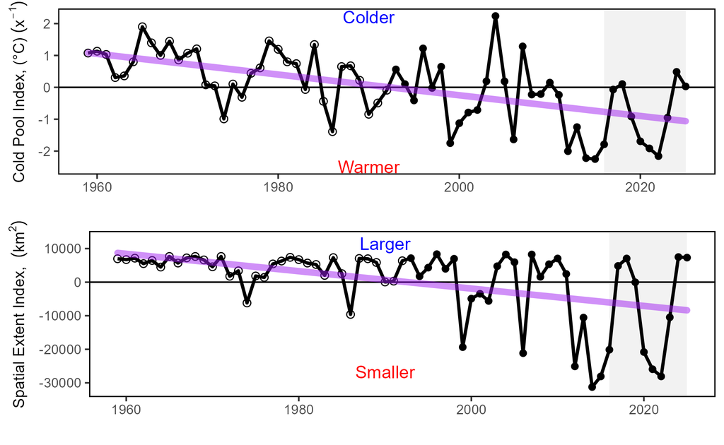

Seasonal cold pool mean temperature (top) and spatial extent index (bottom), based on bias-corrected ROMS-NWA (open circles) and GLORYS (closed circles), with declining trends (purple).

#### Future Considerations

Distribution shifts caused by changes in thermal habitat and ocean circulation are likely to continue as long as long-term trends persist. Episodic and short-term events (see [2024 Highlights](https://noaa-edab.github.io/catalog/observation_synthesis_2024.html) and 2025 Highlights) may increase variability in the trends, however species distributions are unlikely to reverse to historical ranges in the short term. Increased mechanistic understanding of distribution drivers is needed to better understand future distribution shifts: species with high mobility or short lifespans react differently from immobile or long-lived species.

[MOM6 decadal oceanographic forecasts](https://noaa-edab.github.io/catalog/MOM6_forecasts.html) suggest a tendency towards near-normal temperatures over the next decade due to decadal variability in regional circulation. 2026 seasonal forecasts show a high probability of below average surface and bottom temperatures in the winter months. Forecast uncertainty is higher during the spring and summer seasons, and above average conditions are predicted for the fall. These forecasts will continue to be evaluated to determine how well they are able to predict episodic and anomalous events that are outside of the long-term patterns.

Adapting management to changing stock distributions and dynamic ocean processes will require continued monitoring of populations in space and time while evaluating management measures against a range of possible future spatial distributions. The upcoming Climate Vulnerability Assessment 2.0 will also be incorporating MOM6 output and forecasts to help predict changes in species distributions and quantify species exposure to predicted future change. Processes like the [East Coast Coordination Group](https://www.mafmc.org/e3cg) and the HMS Climate Vulnerability Assessment can help coordinate management.

### Risks to managing seasonally

The effectiveness of seasonal management actions (fishing seasons or area opening/closing periods) depends on a proper alignment with the seasonal life cycle events (phenology) of fish stocks (e.g., migration and spawning timing). If not accounted for, changes in the timing of these biological cycles can reduce the effectiveness of seasonal management measures. The timing of seasonal patterns can also change the interactions between fisheries and non-target species thus influencing bycatch and the availability of species to surveys.

#### Indicators: Timing shifts

Indicators of phenological changes in fish populations require regular sampling and observations, and therefore a limited number of these indicators are currently available. One indicator shows shifts in [spawning timing](https://noaa-edab.github.io/catalog/spawn_timing.html) of haddock and yellowtail flounder. Spawning of both haddock stocks occurred earlier in the year, as indicated by more resting (post-spawning) stage fish in recent years compared to earlier in the time series (Fig. $\ref{fig:spawntiming}$). The high percentage of northern stock (Cape Cod/GOM) yellowtail flounder females in the resting maturity stage shown earlier in the time series is reflective of spring surveys sampling them well before spawning, which peaks in June for the northern stock. More recently, the females are much closer to spawning, indicating that yellowtail flounder are spawning earlier in the year. Similarly, increased catch of post-spawning fish in Southern New England, indicates that the peak spawning of the southern stock has also shifted to earlier in the year. Yellowtail flounder spawning is related to bottom temperature, week of year, and decade sampled for each of the three stocks. Changes to spawning times could impact the survival of early life stages of fish, subsequently affecting the larger population size, health, and market value.

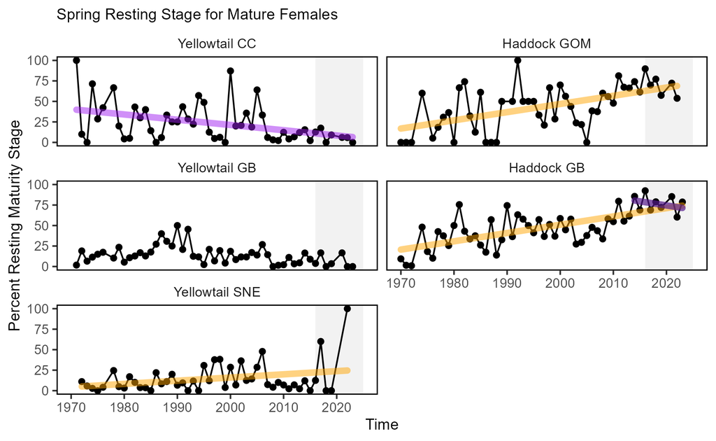

Percent resting stage (non-spawning) mature female fish (black) from spring NEFSC bottom trawl survey with significant increases (orange) and decreases (purple) from two haddock and three yellowtail flounder stocks: CC = Cape Cod Gulf of Maine, GOM = Gulf of Maine, GB = Georges Bank, SNE = Southern New England.

Understanding whether seasonal patterns are changing for stocks requires regular observations throughout the year. For example, baseline work on [cetacean presence in Southern New England](https://noaa-edab.github.io/catalog/cetacean_acoustic.html) shows different seasonal use patterns for whale and dolphin species. Despite the importance of understanding seasonal patterns, we have few indicators that directly assess timing shifts of species. We plan on incorporating more indicators of timing shifts and phenology in future reports.

#### Drivers:

The drivers of timing shifts in managed stocks are generally coupled to shifts in environmental or biological conditions, since these can result in changes in habitat quality or food availability within the year. Changes in the timing of fall phytoplankton blooms and seasonal shifts in zooplankton communities are indicators of changes in seasonal food availability to stocks.

Along with the overall warming trends in the Mid-Atlantic Bight, ocean summer conditions have been lasting longer (Fig. $\ref{fig:transition}$) due to the earlier [transition](https://noaa-edab.github.io/catalog/trans_dates.html) from cool spring conditions to warm summer conditions and the later transition from warm summer conditions to cooler fall temperatures. These transition dates relate how daily temperatures compare to the seasonal norm. Changes in the timing of seasonal environmental cycles can alter biological processes (migrations, spawning, etc.) that are triggered by seasonal events.

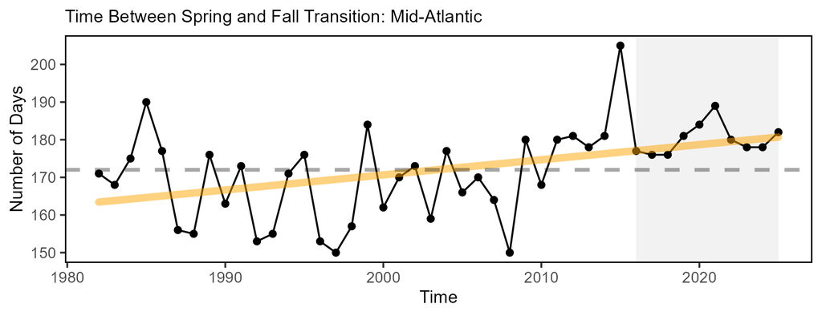

Ocean summer length in the MAB: the annual total number of days between the spring thermal transition date and the fall thermal transition date (black), with an increasing trend (orange). Transition dates are based on sea surface temperatures.

As noted above, the Mid-Atlantic [Cold Pool](https://noaa-edab.github.io/catalog/cold_pool.html) is a summer to early fall feature that creates seasonally suitable habitat for some species. Cold pool persistence has decreased indicating that the duration of the cold pool habitat is shorter compared to the 1960s (Fig. $\ref{fig:cold-pool-time}$). However, all cold pool indices were near or above the long-term average in 2025 and likely related to the influx of northern waters into the system (see [2024 Highlights](https://noaa-edab.github.io/catalog/observation_synthesis_2024.html) ). A change in the timing of the autumn breakdown of the Cold Pool may impact the recruitment of species that rely on it for seasonal cues and habitat. Southern New England-Mid Atlantic yellowtail flounder recruitment and settlement are related to the strength of the MAB Cold Pool (a factor of extent and persistence). The correlation of pre-recruit settlers to the Cold Pool is thought to represent a bottleneck in yellowtail flounder life history, whereby a local and temporary increase in bottom temperature can negatively impact the survival of settlers. Including the effect of Cold Pool variations on yellowtail recruitment reduced retrospective patterns and improved predictive skill in a stock assessment model. This connection is especially important given the long-term decline in the duration of the Cold Pool.

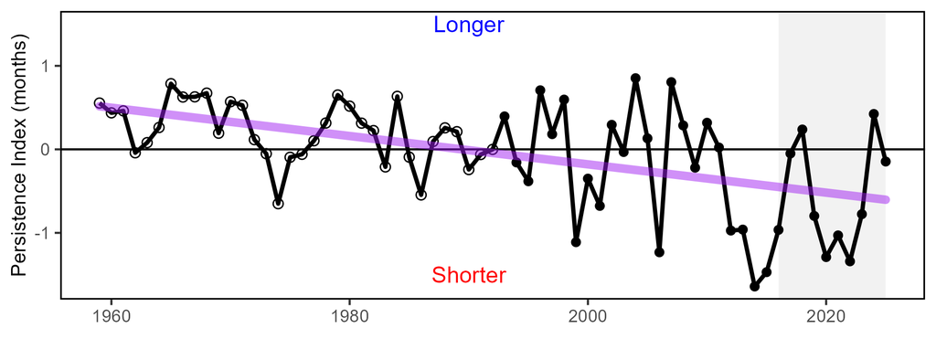

The Mid-Atlantic Bight Cold Pool persistence index based on bias-corrected ROMS-NWA (open circles) and GLORYS (closed circles), with significant long-term decline (purple).

The seasonal timing of Mid-Atlantic [phytoplankton](https://noaa-edab.github.io/catalog/chl_pp.html) blooms shows high interannual variability during the fall bloom period (October-December, Fig. $\ref{fig:chl-month}$). The significant increase in January chlorophyll suggests that the fall bloom period is continuing into the winter, with higher phytoplankton concentrations now than in the late 1990s. The significant decrease of chlorophyll in September could be related to warmer temperatures persisting into early fall and nutrient limitation causing a delay in the fall bloom. Changes to bloom timing can create a mismatch with the timing of larval fish development and may impact recruitment.

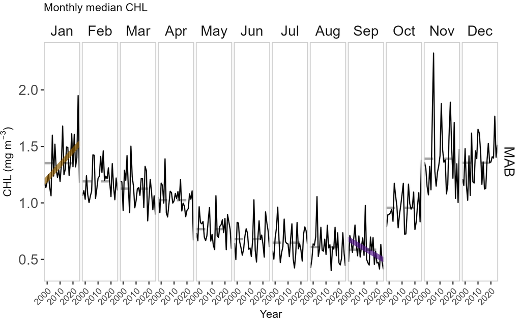

Monthly median chlorophyll a concentration in the MAB (black) with a significant increase present in January (orange) and a significant decline in September (purple).

#### Future Considerations

Species are reliant on environmental processes to dictate the timing of their behavior (e.g., phytoplankton bloom timing, thermal transition, or the duration of the cold pool). Some changes are episodic and have interannual variability, while others may be shifting away from a historic baseline on the scales of years to decades. Other species may rely on the general seasonal succession of environmental drivers (e.g., the timing of the fall turnover) to cue biological processes, and long-term trends in seasonal transitions are unlikely to reverse in coming years. Thus, timing shifts in migration or spawning may continue. Management actions that rely on effective alignment of fisheries availability and biological processes should continue to evaluate whether prior assumptions on seasonal timings still hold, and new indicators should be developed to monitor timing shifts for stocks.

### Risks to setting catch limits

The efficacy of short-term stock projections and rebuilding plans rely on accurate understanding of processes affecting stock growth, reproduction, and natural mortality. These biological processes are often driven by underlying environmental change. If ignored, environmental change may increase the risk that established stock-level biological reference points no longer reflect the current population and increase projection uncertainty, both of which can contribute to quota misspecification.

#### Indicators: Fish productivity and condition shifts

Indicators of [fish productivity](https://noaa-edab.github.io/catalog/productivity_anomaly.html) are derived from observations (surveys) or models (stock assessments). Fish productivity declined during the 1990’s and 2000’s with declining production of summer flounder and has been variable since, as described by the small-fish-per-large-fish anomaly indicator (derived from NEFSC bottom trawl survey) (Fig. $\ref{fig:productivity-anomaly}$). Bluefish, black sea bass, and goosefish have sporadic years with large positive anomalies, but most years have small negative anomalies. This decline in fish productivity is also shown by a similar analysis based on stock assessment model outputs (recruitment per spawning stock biomass anomaly). Most species had positive recruitment anomalies in the 1990s and 1990s and are currently showing negative anomalies, indicating a decline in productivity. Fish productivity can be affected by parental condition, environmental conditions, timing and availability of prey for recruits, as well as retention of recruits within favorable habitat. High offshore advection during spawning seasons can reduce recruitment success and affect overall fish productivity.

The health of individual fish (i.e., fish condition, measured as weight for a given length) can contribute to population productivity through improved growth, reproduction and survival. Mid-Atlantic [fish condition](https://noaa-edab.github.io/catalog/condition.html) was generally high to very high prior to 2000, low to very low from 2001-2010 (concurrent with declines in productivity, Fig. $\ref{fig:productivity-anomaly}$)), and mixed since 2011. In 2025, condition continued to be mixed, with general improvement since a relatively low condition year in 2021 (Fig. $\ref{fig:mab-cf}$). Preliminary analyses show that years dominated by small copepods and warmer spring temperatures may improve fish condition for Atlantic mackerel and butterfish. Similar environmental drivers may be important to other species.

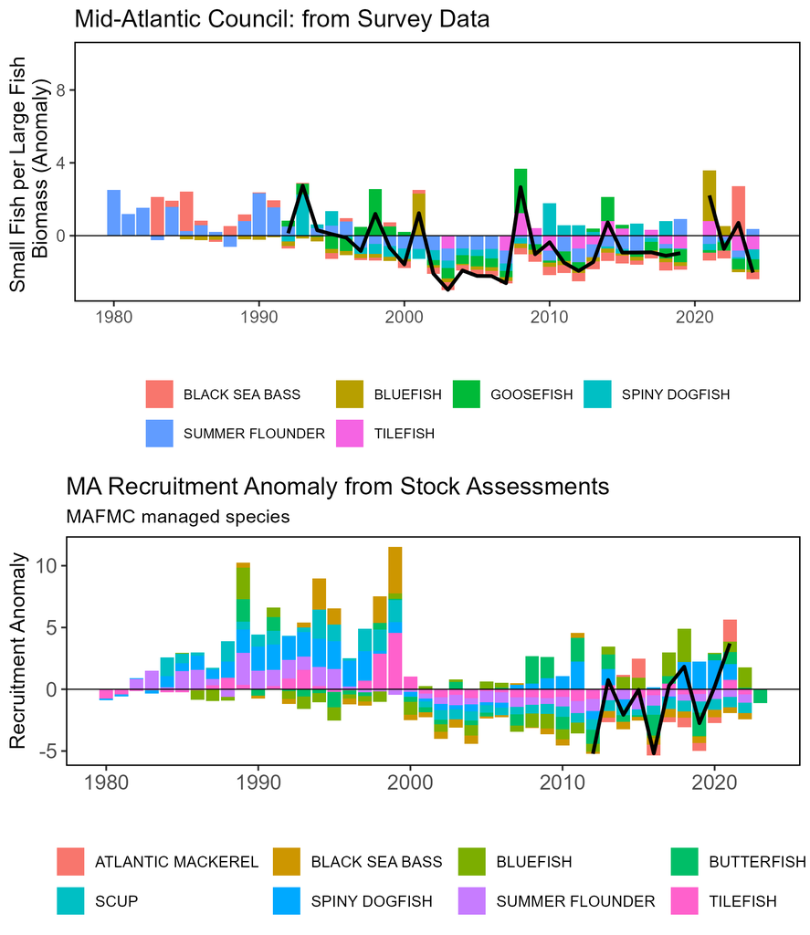

Fish productivity measures. Top: Small fish per large fish survey biomass anomaly of Mid-Atlantic Fishery Management Council managed species in the Mid-Atlantic Bight. Bottom: assessment recruitment per spawning stock biomass anomaly for stocks managed by the Mid-Atlantic Fishery Management Council. The summed anomaly across species is shown by the black line, drawn across all years with the same number of stocks analyzed.

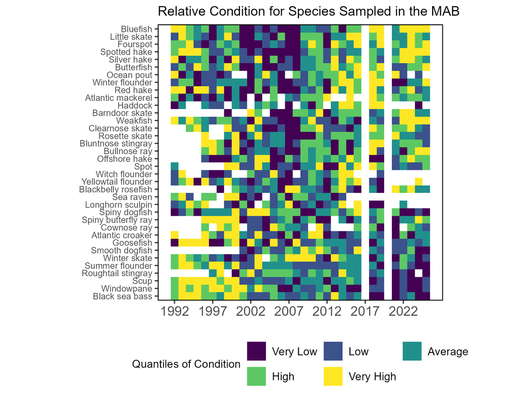

Condition factor for fish species in the MAB based on fall NEFSC bottom trawl survey data. MAB data are missing for 2017 due to survey delays, and no survey was conducted in 2020.

#### Drivers:

Fish productivity and condition are the cumulative effects of physiological, ecological, and environmental factors. Major factors include increased metabolic demands from increasing temperature and changes in the availability and quality of prey. Long-term environmental trends and episodic extreme temperatures, ocean acidification, and low oxygen events represent multiple stressors that can affect growth rates, reproductive success, recruitment, and cause mortality.

##### Biological Drivers: Forage quality and abundance

The energy density (ED) of prey, in conjunction with its mass, indicates the total amount of energy available to higher trophic level predators. The quality and abundance of this forage base directly impact the productivity and movement of managed and protected species. Management should consider these energetic links, as shifts in forage quality can alter the health of individual stocks and the entire ecosystem.

Forage fish [energy content](https://noaa-edab.github.io/catalog/energy_density.html) fluctuates based on growth, reproduction, environmental conditions, and ecosystem productivity. In the Mid-Atlantic Bight, butterfish are the most abundant high ED forage species (Fig. $\ref{fig:energy-density}$), though their fall ED have recently declined toward lower spring averages. Atlantic herring and Atlantic mackerel also serve as high-energy prey, but herring show recently low ED and declining abundance, while mackerel are most abundant in the spring despite having higher ED in the fall. Moderate energy forage species (longfin squid, northern shortfin squid, and silver hake) are of intermediate abundance and show minimal annual and seasonal variation in ED. Other species have high ED but lower abundance decreasing their reliability as a food source.

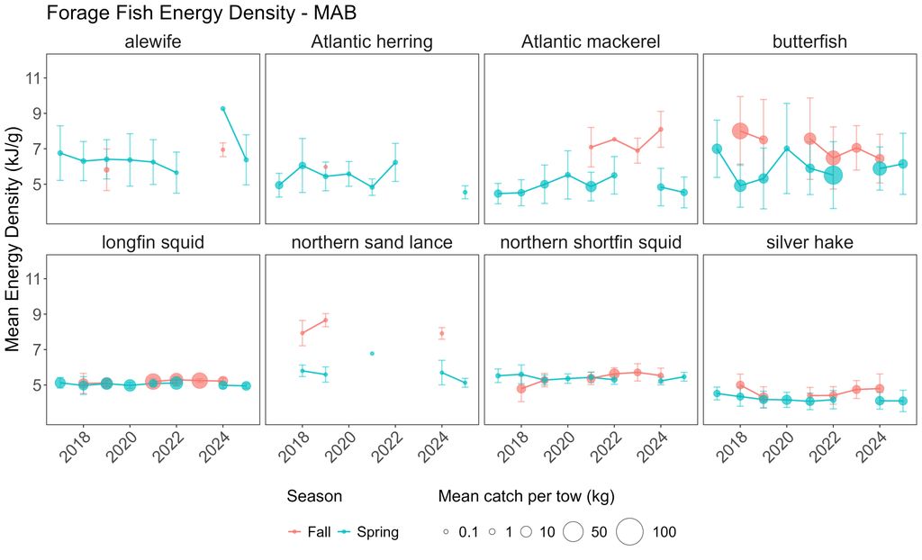

Energy density (mean and standard deviation) of eight forage species from NEFSC bottom trawl surveys by season and year for the MAB. Symbol size represents abundance (mean kg/tow) estimated from bottom trawl survey tows in the MAB.

Changes in the overall abundance of forage fish can influence managed species productivity as it relates to changes in food availability. A spatially-explicit [forage index](https://noaa-edab.github.io/catalog/forage_index.html) for the Mid-Atlantic shows a long term declining trend in fall, with higher forage biomass in fall than spring (Fig. $\ref{fig:foragebio}$). Forage biomass was highest during fall in the early-1980s. The decrease of fall forage biomass in the Mid-Atlantic may reduce the health and reproductive output of fish species. Additionally, this may be exacerbated by lower energy densities of prey, especially in years of higher water temperatures when metabolic demands are higher.

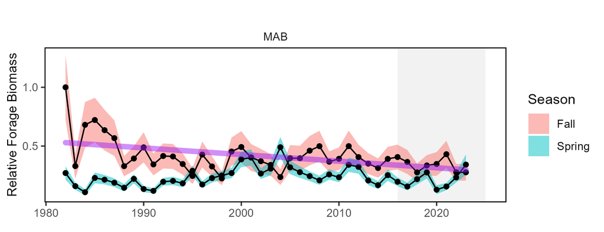

Forage fish index in the MAB for spring (blue) and fall (red) surveys, with a decline (purple) in fall. Index values are relative to the maximum observation within a region across surveys.

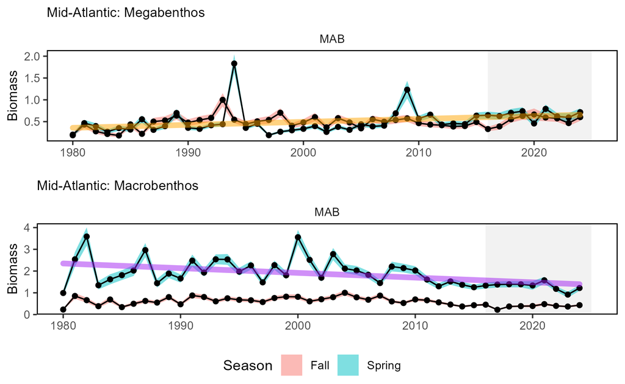

Changes in spring (blue) and fall (red) benthos abundance in the MAB for megabenthos (top) and macrobenthos (bottom), with significant long-term increasing trend (orange) for megabenthos and decreasing trend (purple) for macrobenthos in spring.

##### Biological Drivers: Lower trophic levels

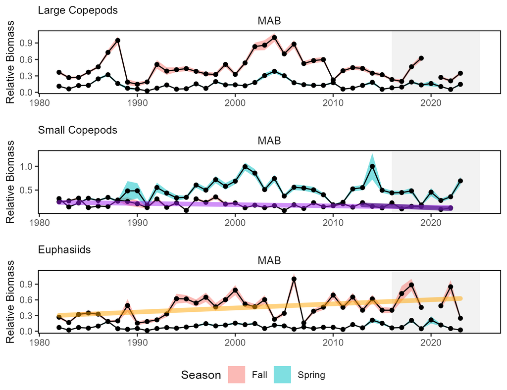

##### Environmental Drivers

Fish production can also be directly related to the prevailing environmental conditions by altering metabolism (growth), reproductive processes, and survival. Marine species possess thermal tolerances and can experience stressful or lethal conditions if water temperatures exceed certain levels. We have observed in past years extreme temperatures at both the [surface](https://noaa-edab.github.io/catalog/seasonal_oisst_anom.html) and [bottom](https://noaa-edab.github.io/catalog/bottom_temp_model_anom.html) that exceed [thermal tolerance](https://noaa-edab.github.io/catalog/thermal_habitat_gridded.html) limits for some fish and shellfish. However, in 2025, Mid-Atlantic surface and bottom temperatures were near or below the long-term average and the amount of habitat exceeding a 24 oC thermal tolerance was limited to the southern MAB, where those conditions occurred for fewer than 30 days (Fig. $\ref{fig:therm-hab-persist-2024}$).

A single surface [marine heatwave](https://noaa-edab.github.io/catalog/heatwave.html) occurred in the Mid-Atlantic Bight in 2025, starting July 15th and lasting seven days. This brief event was the only heatwave recorded across the entire Continental Shelf for the year. The MAB experienced six surface marine [cold spells](https://noaa-edab.github.io/catalog/cold_spell.html) in 2025, including an event in February that ranked as the 8th strongest on record. Additionally, a significant bottom cold spell occurred in January, lasting 57 days and ranking as the 5th strongest on record. During this period, bottom temperatures averaged 7.2 °C, nearly 2 °C lower than the historical average.

Lower ocean temperatures near long-term averages will affect species differently across the region. While cold-water species like cod may benefit from these conditions, warm-water species such as black sea bass are unlikely to see positive effects. This variability in regional cooling highlights the need for management to account for shifting species distributions and productivity.

[figure not shown]

Marine cold spells based on detrended GLORYS12V1 bottom temperature from July 2024 though December 2025 in the MAB. Cold spells defined by events where observered temperature (black) exceeds a threshold (green) based on the climatology (blue). Blue shaded areas show the cold spell events with the largest event in dark blue.

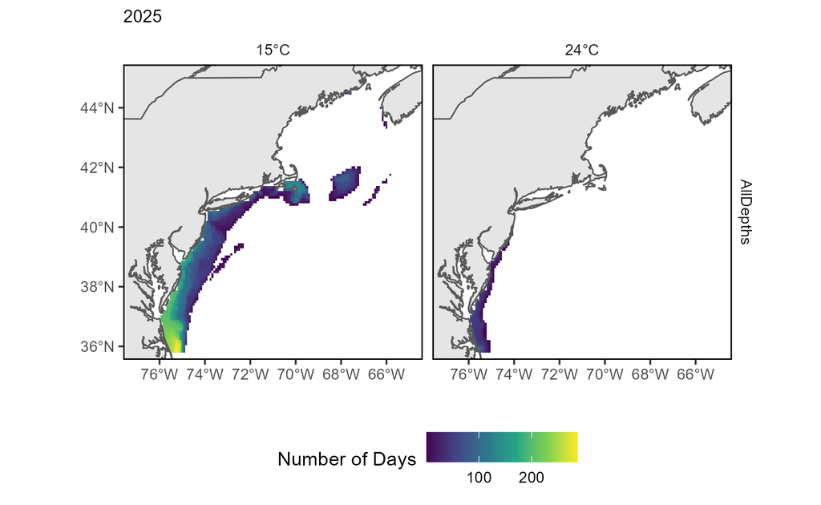

The number of days in 2025 where bottom temperature exceeds 15 degrees (left) and 24 degrees (right) based on the GLORYS 1/12 degree grid.

The newly-developed [advection index](https://noaa-edab.github.io/catalog/advection.html) (Fig. $\ref{fig:advection-index}$) shows total transport of water onto and off the continental shelf which can impact the survival of early life stages of fish and invertebrates. Long-term trends in the Mid-Atlantic show increased offshore movement of surface and bottom waters in June, which could decrease retention of some species. Further species level studies are needed to link spawning timing and larval periods to advection trends at the corresponding spatial and temporal scalesdepth and month.

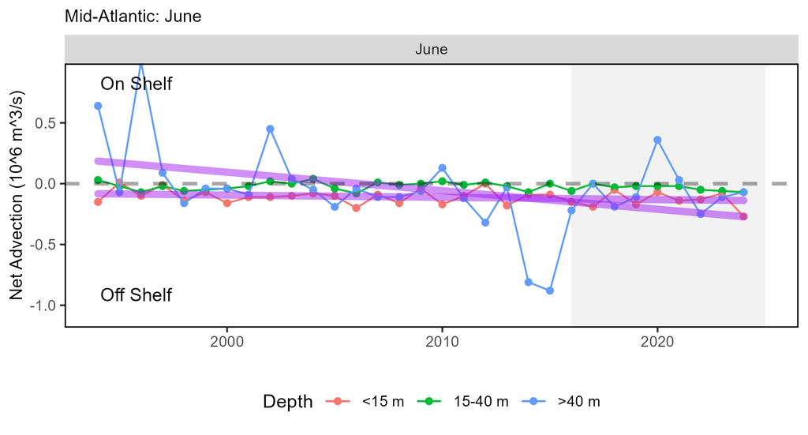

Net advection in June across the Mid-Atlantic continental shelf break within 3 depth bands.

[Ocean acidification](https://noaa-edab.github.io/catalog/ocean_acidification.html) (OA) risks vary among species and include reduced survival, growth, reproduction, and productivity, where high OA risk indicates potential negative effects to species. OA risk can also be heightened during colder conditions due to increased CO2 absorption by colder water or by transport of high CO2 water masses as was suggested to have occurred in 2024 (see [2024 Highlights](https://noaa-edab.github.io/catalog/observation_synthesis_2024.html)). The OA indicator observed on the Mid-Atlantic coastal shelf during summer 2024 was the most extreme recorded when compared to all of the years sampled (since 2007). In 2025, however, OA risk conditions were less than those observed in 2023 and 2024. High OA conditions in 2025 were limited to a few outer shelf coastal New Jersey (NJ) observations in spring, where sensitivity levels for Atlantic sea scallops were exceeded (not shown, see [ocean acidification](https://noaa-edab.github.io/catalog/ocean_acidification.html)), and in nearshore NJ waters in summer, where sensitivity levels for Longfin squid were reached (Fig. $\ref{fig:mab-oa}$). Although relatively cool bottom seawater temperatures in 2025 were similar to 2024, salinity was higher in 2025, which suggests a different composition of oceanographic properties and water masses between the two years and as a result, different OA risk conditions.

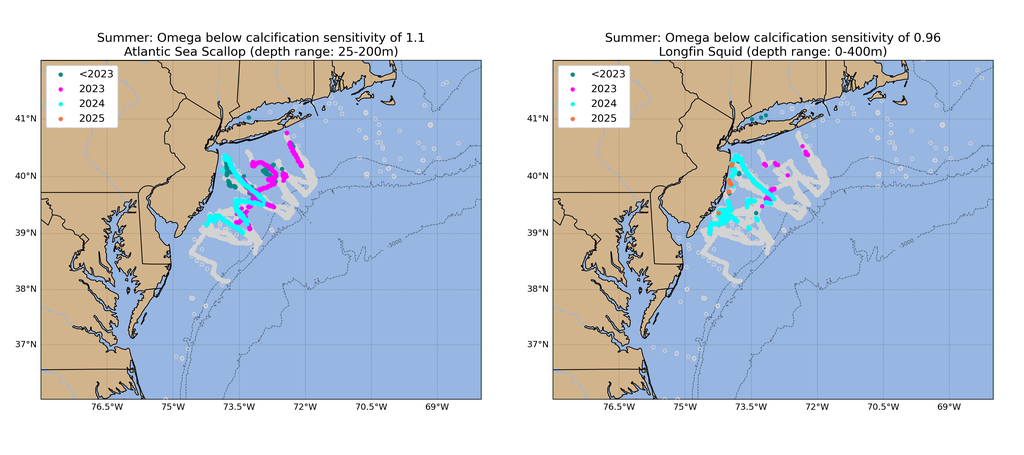

[Low dissolved oxygen levels](https://noaa-edab.github.io/catalog/dissolved_oxygen.html) (< 5 mg/L) remained localized and brief on the [MAB shelf in 2025](https://noaa-edab.github.io/catalog/observation_synthesis_2023.html), resulting in no industry-reported mass mortality events despite the potential for hypoxia to reduce species growth or cause death. Localized hypoxia (< 2 mg/L) occurred nearshore east of Point Pleasant, NJ, southwest of Newport, RI, and at the western end of the Cape Cod Canal, while broader shelf-wide levels below 5 mg/L were not widespread. This contrast follows previous years where [hypoxic](https://noaa-edab.github.io/catalog/observation_synthesis_2023.html) events in Cape Cod Bay (2019, 2020) and off New Jersey (2023) potentially caused fish, lobster, and crab [mortality](https://sebsnjaesnews.rutgers.edu/2023/12/rutgers-scientists-observe-unusual-ocean-conditions-possibly-linked-to-mortality-in-marine-life-off-new-jersey/). While shelf-wide monitoring data is currently limited, biological and oceanographic drivers of oxygen levels continue to be tracked to assess the duration and extent of future events.

##### Drivers: Predation

The abundance and distribution of marine mammal, shark predators, and other Atlantic Highly Migratory Species (HMS), can affect both the productivity and mortality rates on managed stocks. Predators can consume managed species or compete for the same resources, resulting in increased natural mortality or decreased productivity. The northeast shift in [whales and dolphins](https://noaa-edab.github.io/catalog/cetacean_dist.html) (Fig. $\ref{fig:protectedspp-dist-shifts}$) indicates a change in the overlap between marine mammals and managed fishes. Since we also observe distribution shifts in managed species as well as forage species, the effect of changing predator distributions alone is difficult to quantify.

Indicators for shark populations, combined with information on gray seals (see Protected Species Implications section, above), suggests predator populations range from stable ([sharks](https://noaa-edab.github.io/catalog/hms_cpue.html)) to increasing ([gray seals](https://noaa-edab.github.io/catalog/seal_pups.html)) in the MAB. [Stock status](https://noaa-edab.github.io/catalog/hms_stock_status.html) is mixed for HMS stocks (including sharks, swordfish, billfish, and tunas) occurring throughout the Northeast U.S. shelf. While there are several HMS species considered to be overfished or that have unknown stock status, the population status for some managed Atlantic sharks and tunas is at or above the biomass target, suggesting the potential for robust (or rebuilt) predator populations and subsequent predation pressure on managed species. Increasing predator populations or changing distribution of predators may result in increased predation pressure.

## Other Ocean Uses: Offshore Wind

Offshore wind development is active and dynamic throughout the region. The following section reflects the status of projects as of 5 February, 2026.

### Indicators: development timeline, revenue in lease areas, coastal community vulnerability

All reported potential offshore wind development status and data are based on BOEM’s Offshore Renewable Activities page and projects’ Final Environmental Impact Statements. In 2025, the Presidential Memorandum 90 FR 8363 removed existing planning areas and excluded the establishment of additional lease areas.

As of January 2026, 38 offshore [wind development](https://noaa-edab.github.io/catalog/wind_dev_speed.html) leases are under different stages of development in the Northeast (Fig. $\ref{fig:wind-dev-cumul}$). One project (South Fork Wind Farm) is fully operational and another (Vineyard Wind 1) is partly operational while construction finishes. The southern New England region has two other projects currently under construction (Revolution Wind and Sunrise Wind). Empire Wind and Coastal Virginia Offshore Wind (CVOW) are currently under construction in the New York Bight and Mid-Atlantic Region, respectively, with CVOW expected to start generating power in early 2026.

With the first offshore wind energy projects now under construction and operation, all indicator analyses in this section follow a different reporting format than in previous years. Where previous years reported data for all lease areas, this year we investigate impacts of the six commercial scale projects currently under construction or operation, (i.e., Active Projects: South Fork Wind Farm, Revolution Wind, Sunrise Wind, Empire Wind 1, Vineyard Wind 1, and CVOW-Commercial).

[figure not shown]

All Northeast Project areas by year construction ends (each project has a 2 year construction period).

Offshore wind indicators are based on federal logbook data and do not include all data for all fisheries; therefore a complete evaluation of potential offshore wind energy development impacts would need to be supplemented by other data sources. For further information on the utility of the data, see the [socioeconomic impacts of offshore wind development data reports page](https://www.fisheries.noaa.gov/resource/data/socioeconomic-impacts-atlantic-offshore-wind-development).

Based on federal vessel logbook data, [commercial fishery revenue](https://noaa-edab.github.io/catalog/wind_revenue.html) from trips within Active Projects have varied annually from 2008-2024, with less than $500,000 in maximum annual revenue overlapping with these areas for most fisheries with the exception of the longfin squid ($2 million), monkfish ($1.1 million), ocean quahog ($783,000), and summer flounder ($556,000) in specific years (Fig. $\ref{fig:wea-spp-rev}$).

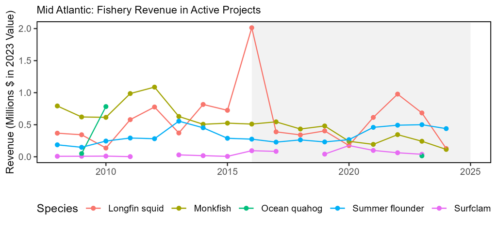

Revenue of species managed by the Mid-Atlantic Fishery Management Council within Active Projects.

Within Active Projects, the MAFMC managed fisheries most affected based on historic landings include longfin squid, monkfish, scup, Atlantic mackerel, and summer flounder, with a maximum of 6% of annual regional fishery revenue for chub mackerel occurring within Active Projects during 2008-2024, 5% for bluefish, 4% for butterfish, and 3% each for monkfish, scup, black sea bass, and longfin squid, respectively (see Table $\ref{tab:wea-landings-rev}$). Future offshore wind development may increase effects on these and additional species if more projects begin construction. Future fishery resource overlap with wind leases, especially surfclams and ocean quahogs, may change due to species distribution shifts attributable to climate change and recruitment and larval dispersion pattern changes caused by hydrodynamic flow disruptions from turbine foundations, which could also affect fishery landings/revenue.

Top 10 Mid-Atlantic managed species Landings and Revenue from Active Projects. *Less than a maximum of 50,000 lb was reported landed annually in wind energy lease areas for these species.

| NEFMC, MAFMC, and ASMFC Managed Species | Maximum Percent Total Annual Regional Species Landings | Maximum Percent Total Annual Regional Species Revenue |
| --- | --- | --- |
| Chub Mackerel* | 5.32 | 5.80 |
| Bluefish* | 3.60 | 4.85 |
| Butterfish | 4.37 | 3.88 |
| Scup | 3.32 | 3.26 |
| Longfin Squid | 3.31 | 3.25 |
| Monkfish | 4.66 | 3.23 |
| Black Sea Bass | 2.70 | 3.01 |
| Atlantic Mackerel | 2.93 | 2.40 |
| Ocean Quahog | 2.21 | 2.34 |
| Summer Flounder | 1.78 | 2.01 |

The socio-demographic conditions, and resultant vulnerabilities, of some communities may further exacerbate the impacts of offshore wind development in the Northeast such that the impacts of offshore wind development are expected to differentially [impact specific coastal communities](https://noaa-edab.github.io/catalog/wind_port.html) (Fig. $\ref{fig:wea-port-rev}$)

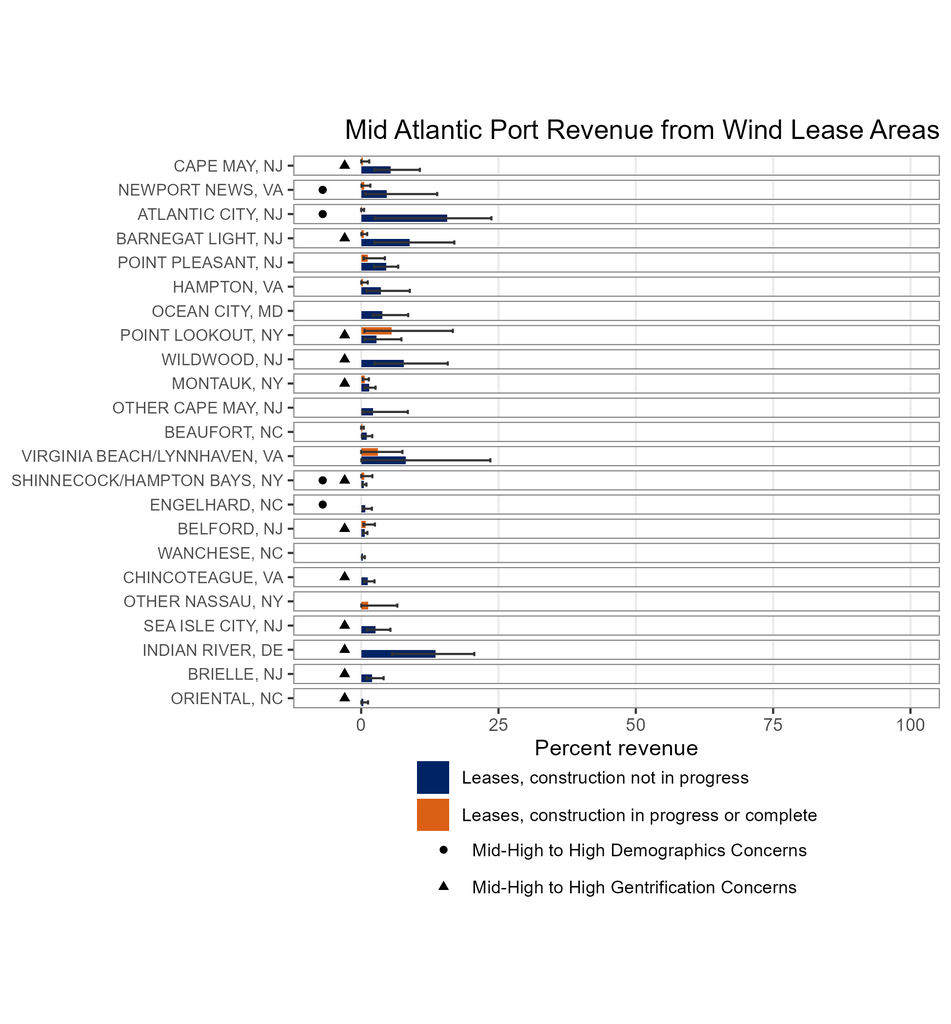

Percent of Mid-Atlantic port revenue from Wind Energy Areas (WEA) from leases not under construction (blue) and active leases (orange). Note that North Carolina fisheries management is split between the Northeast and Southeast, and this plot only includes data reported to the Northeast Fisheries Science Center.

Based on federal vessel logbook data, Point Lookout, NY (5.5% average, 17% maximum) and Virginia Beach, VA (3% average, 7.5% maximum) have the highest potential revenue loss from the Active Projects based on 2008-2024 total port fisheries revenue. Fewer Mid-Atlantic ports are affected by the Active Projects to date, as most are in the southern New England region, with the exception of CVOW and Empire Wind 1 (Fig. $\ref{fig:wea-port-rev}$). Additional fishing revenue may be lost as more areas historically used for fishing are developed for offshore wind energy. In seven New England ports, Mid-Atlantic managed species account for at least 50% of landings from the Active Project areas by value or weight (Fig. $\ref{fig:wind-rev}$). Furthermore, impacts of offshore wind development may unevenly affect individual operators, with some permit holders deriving a much higher proportion of revenue from wind areas than the port-based mean.

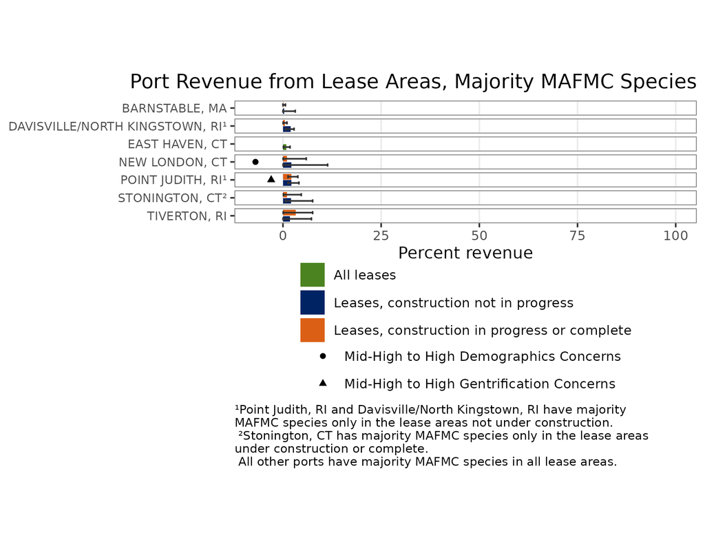

If all proposed projects are developed, BOEM reports that cumulative offshore wind development could have moderate impacts on low-income members of communities who work in the commercial fishing and for-hire fishing industry due to disruptions to fish populations, restrictions on navigation and increased vessel traffic, and existing vulnerabilities of low-income workers to economic impacts.

Top fishing communities with both landings from the Active Projects (i.e., Point Lookout, NY and Newport News, VA) and [socio-demographic or gentrification concerns](https://noaa-edab.github.io/catalog/engagement.html) should be recognized as having additional vulnerability from Active Projects. To reduce further social and economic impacts and aid in the resilience and adaptive capacity of these communities, this vulnerability should be considered in decision making. Historically, the introduction of new industries can trigger industrial and socioeconomic gentrification of fishing ports. Competition for port space and potential pivoting of space use for offshore wind development should be monitored closely to ensure fishing communities are not adversely impacted. Additionally, offshore wind could increase recreational fishing opportunities at the turbines, potentially creating a demand for additional tourism, recreational fishing and boating port space in communities already balancing these uses with commercial fishing infrastructure(e.g., Virginia Beach, VA, Montauk, NY and Barnegate Light, NJ.) Socio-demographic concerns also highlight communities where further resources are needed to reach underserved and underrepresented groups and create opportunities for, and directly involve, these groups in the decision-making process.

### Implications

Current plans for buildout of offshore wind in a patchwork of areas spreads the impacts differentially throughout the region (Fig. $\ref{fig:wind-dev-cumul}$). Up to 6% of maximum annual fisheries revenue for major Mid-Atlantic commercial species in lease areas could be forgone or reduced and associated effort displaced if all sites are developed. Displaced fishing effort can alter historic fishing area, timing, and method patterns, which can in turn change habitat, species (managed and protected), and fleet interactions. Several factors, including fishery regulations, fishery availability, and user conflicts affect where, when, and how fishing effort may be displaced, along with impacts to and responses of affected fish species.

Proposed wind development areas interact with the region’s federal scientific surveys. Scientific surveys are impacted by offshore wind in four ways: 1. Exclusion of NOAA Fisheries’ sampling platforms from the wind development area due to operational and safety limitations. 2. Impacts on the random-stratified statistical design that is the basis for scientific assessments, advice, and analyses. 3. Alteration of benthic and pelagic habitats, and airspace in and around the wind energy development, requiring new designs and methods to sample new habitats. 4. Reduced sampling productivity through navigation impacts of wind energy infrastructure on aerial and vessel survey operations.

Increased vessel transit between stations may decrease data collections that are already limited by annual days-at-sea day allocations. In the Northeast region, 14 [NEFSC surveys](https://noaa-edab.github.io/catalog/osw_survey_impact.html) overlap with offshore wind development projects at varying capacities, with each of the 38 existing lease areas overlapping between 4-14 surveys. The Active Projects overlap between 10-12 surveys. Implementation of the region-wide survey mitigation program is underway with requirements to mitigate impacts to surveys included as a condition of most project approvals.

Planned development [overlaps NARW](https://noaa-edab.github.io/catalog/persistent_hotspots.html) mother and calf migration corridors and a significant foraging habitat that is used throughout the year (Fig. $\ref{fig:whales-wind}$). Turbine presence and extraction of energy from the system could alter local oceanography and may affect right whale prey availability. For example, persistent foraging hotspots of right whales and seabirds overlap on Nantucket Shoals, where unique hydrography aggregates enhanced prey densities. Wind leases (OCS-A 0521 and OCS-A 0522) currently intersect these hotspots on the southwestern corner of Nantucket Shoals and a prominent tidal front associated with invertebrate prey swarms important to seabirds and possibly right whales. Proposed wind development areas also bring increased vessel strike risk from construction and operation vessels. In addition, there are a number of potential impacts to whales from pile driving and operational noise such as displacement, increased levels of communication masking, and elevated stress hormones.

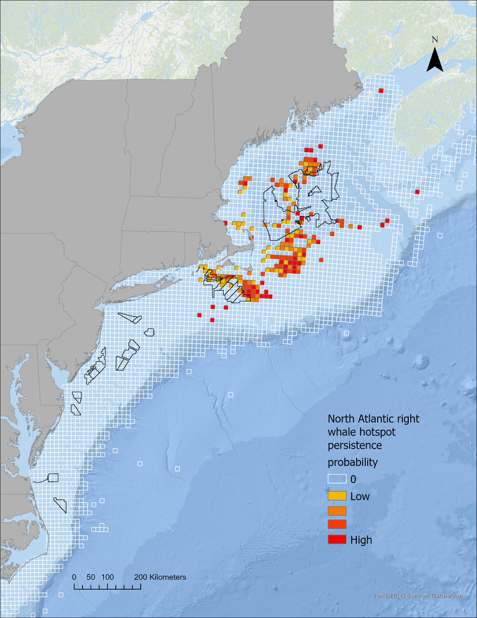

North Atlantic Right Whale persistent hotspots (red shading) and Wind Energy Areas (black outlines).

#### Marine Aquaculture

Aquaculture fisheries and federally-managed fisheries could both compete or benefit each other with spatial access, shoreside infrastructure, or the supply of seafood. Unlike offshore wind, offshore aquaculture is not regulated by any federal leasing program but is permitted via the U.S. Army Corps of Engineers and the U.S. EPA. Currently, there are no federally-permitted aquaculture projects in the Northeast U.S. The marine aquaculture industry of the Northeast currently occurs in nearshore waters which are regulated by state leasing and permitting processes and federal permitting processes, as applicable. Analyses are needed to quantify the nearshore spatial distribution of aquaculture in the Northeast.

### 2025 Highlights

This section intends to provide a record of [noteworthy observations reported in 2025](https://noaa-edab.github.io/catalog/observation_synthesis_2025.html) across the Northeast U.S. region. The full ecosystem and fisheries impacts of many of these observations are still to be determined. They should, however, be noted and considered in future analyses and management decisions.

The Northeast U.S. region experienced colder than average ocean temperatures, despite record warm [global](https://www.ncei.noaa.gov/news/global-climate-202513) ocean and air temperatures. Similar to 2024, oceanographic and ecological conditions reflected cooler water and changing species abundance, distribution, and timing.

#### Northwest Atlantic Phenomena

The below average temperatures observed in 2024 persisted into 2025, although there are seasonal and local exceptions to this pattern. Anomalously cold surface conditions (Fig. $\ref{fig:slopesea}$) were recorded throughout the Northeast Shelf and were widespread across the Slope Sea for much of the year, however the waters were not as fresh as recorded in 2024. Winter bottom temperatures were also below average across much of the Northeast Shelf (Fig. 96b). Multiple oceanographic and atmospheric factors can contribute to these cooler conditions including a more southerly Gulf Stream and higher proportions of Labrador Slope and Scotian Shelf water entering the system.

[figure not shown]

January 2025 sea surface (left) and bottom (right) temperature differences compared to the January climatological means. Sea Surface Temperature (SST) is from the NOAA Advanced Clear-Sky Processor for Ocean (ACSPO) Super-collated SST (climatology range 2000-2020); Bottom temperature is from the GLORYS reanalysis model (climatological range 1990-2020).

In 2024, the Gulf of Maine [source water](https://noaa-edab.github.io/catalog/slopewater.html) entering through the Northeast Channel was near equal proportions of Warm Slope Water and cooler Labrador Slope Water (Fig. 97); data are still being processed for 2025. The colder conditions [observed in 2024](https://noaa-edab.github.io/catalog/observation_synthesis_2024.html) continued into 2025 and contributed to the increased size and colder temperatures of the Mid-Atlantic [Cold Pool](https://noaa-edab.github.io/catalog/cold_pool.html).

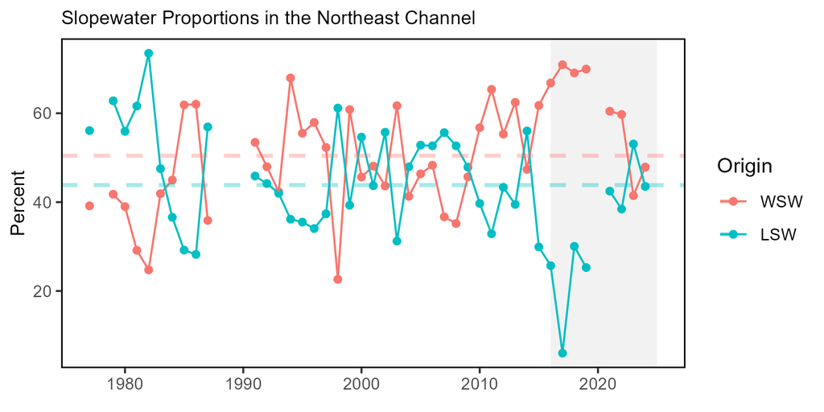

The proportion of Warm Slope Water (WSW) and Labrador Slope Water (LSW) entering the Gulf of Maine through the Northeast Channel from 1977 to 2024. The red and teal dashed lines represent the long-term proportion averages for the WSW and LSW respectively.

2025 total primary production was below average in Georges Bank and the Mid-Atlantic due to lower phytoplankton biomass and cooler sea surface temperatures. [Phytoplankton biomass](https://noaa-edab.github.io/catalog/chl_pp.html?q=phyt#chl_pp) (shown as chlorophyll a concentration) was also below average for much of 2025 (Fig. $\ref{fig:chl-anom}$). In particular, the winter-spring bloom period, which typically accounts for a significant proportion to total annual phytoplankton production, was shorter in duration and lower in magnitude across the entire Northeast shelf region. The fall bloom period was above average in the Gulf of Maine and Georges Bank, but near average in the Mid-Atlantic.

[figure not shown]

Chlorophyll anomalies shown as the ratio of the monthly concentration compared to the climatological mean (1998-2020) for April (left) and October (right), 2025.

Hurricane Erin was the most notable storm in the region in 2025 and caused significant shoreside and oceanographic disturbances despite not making landfall in the Northeast. Its strong winds and large size caused mixing and weakened stratification throughout the Mid-Atlantic resulting in cooler than average surface waters across the shelf and into the Slope Sea. Along the coast, beaches from Maryland to Maine were closed due to rough surf, large waves, and rip currents, while coastal flooding led to road closures and several water rescues, particularly in New Jersey. Beach erosion was significant in some locations.

#### Northeast Shelf and Local Phenomena

The shift to cooler waters in 2024-2025 is likely linked to multiple observations across the Northeast Shelf including the uncommon presence of Arctic zooplankton species in the Gulf of Maine, delayed migration of many species, and redistribution of some species. These shifts could affect the availability of some species to surveys or fishing, although aggregate species distributions in the cooler 2024-2025 period are tracking on the long-term trend towards northward and deeper waters (Fig. $\ref{fig:species-dist}$).

Mid-Atlantic scallops in the Elephant Trunk region are showing positive signs following the [documented die-off](https://noaa-edab.github.io/catalog/observation_synthesis_2023.html). Two-year olds observed in 2024 had good survival into the 2025 survey. The Elephant Trunk region is scheduled to reopen in 2026. There was also good survival of the [2024 recruits](https://noaa-edab.github.io/catalog/observation_synthesis_2024.html) in the southeastern [Nantucket Lightship Area in 2025](https://noaa-edab.github.io/catalog/observation_synthesis_2025.html). In contrast, large numbers of the scallop predator *Asterias vulgaris* sea stars were linked to an increased sea scallop mortality in 2024 and 2025 on Georges Bank.

Several members of the fishing community noted changes in species composition, distribution, and timing in their typical fishing grounds and attributed it to the cooler temperatures. These observations may not fully represent the entire ecosystem, but provide local context to recent events that may not be represented in other indicators. Some notable examples include:

- Several members of the fishing industry reported that it was a “very good year” for billfish. According to the Large Pelagic Survey, it was a record year for white marlin with more than 23,000 fish caught and released. Billfish effort may have been higher than usual due to the closure of the recreational bluefin tuna fishery in August 2025.
- Chesapeake Bay anglers reported good catch of red drum in 2024, followed by low catch and even cold stunned red drum and spotted sea trout in 2025. Scientists working with charter captains in Chesapeake Bay reported low catch rates of striped bass and red drum from June-September, but higher catch rates in the early spring and fall.
- Fishers attributed the delayed migration of black sea bass inshore, and scup migrating south for the winter using similar routes as in the early 1970s due to the cooler temperatures.
- Members of the bluefish fishery in Rhode Island reported very low landings in 2025 attributed to changes in seasonal migration path or timing.
- Some species, such as Atlantic mackerel, Illex squid and sandlance, were observed in higher abundance and wider distributions compared to recent years.
- Fishers in the Gulf of Maine and Georges Bank had mixed reports of lobsters and good catch of sea scallops.
- Fishers reported fewer warm water species in 2025 along the New Jersey coast. Others, however, noted more new species (e.g., pomapano, spadefish, triggerfish, Spanish and king mackerel) in Delaware Bay.
- Anglers also observed low spring and summer catches of gamefish in Mid-Atlantic bays and on the shelf, and high concentrations of shark species near the coast.

In Chesapeake Bay, colder than average winter 2025 temperatures (Fig. 100) were reported by state agencies as a likely cause of higher blue crab mortality rates compared to the previous winter. Colder winters generally indicate good conditions for striped bass spawning, and while the striped bass juvenile index slightly improved, it was still well below the long-term average. Several years of low striped bass recruitment is a growing concern of fisheries managers. Factors that could be influencing striped bass include below average winter-to-spring freshwater flow and above average water temperatures combined with stressful dissolved oxygen values during the summer. The continued presence of invasive blue catfish and the effect they are having on blue crab, alosines, menhaden, and striped bass populations is also a management concern.

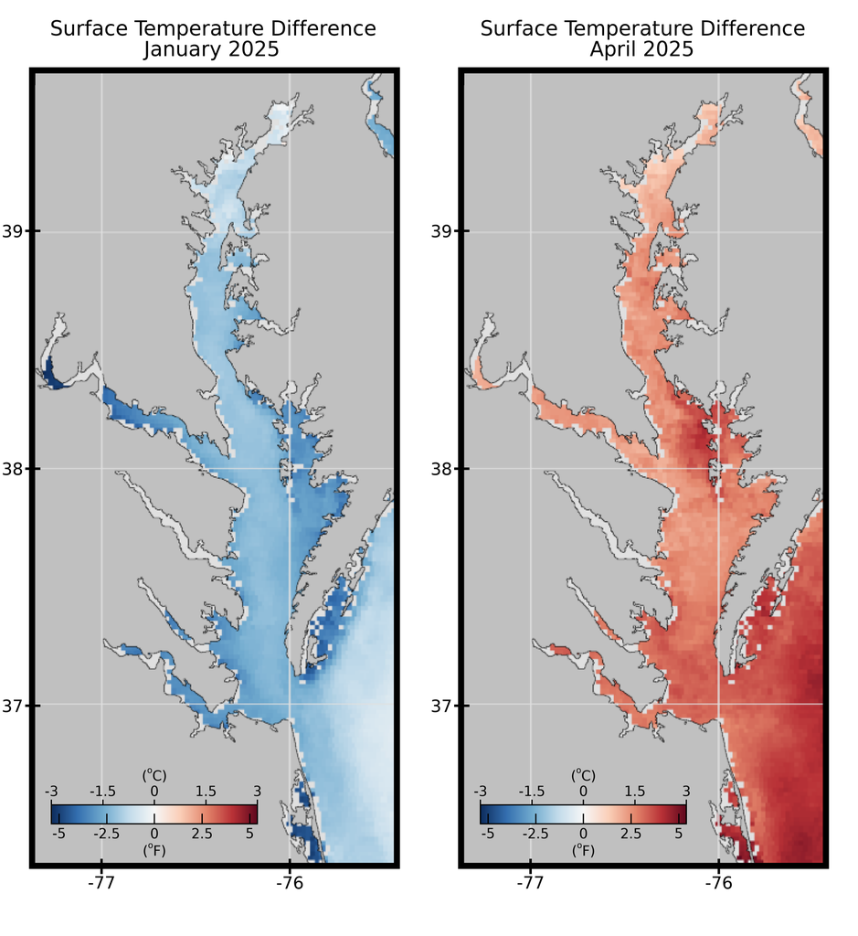

January 2025 (left) and April 2025 (right) sea surface temperature differences compared to the respective monthly climatological means. Sea Surface Temperature (SST) is from the NOAA Advanced Clear-Sky Processor for Ocean (ACSPO) Super-collated SST (climatology range 2000-2020).

[Ocean acidification (OA)](https://noaa-edab.github.io/catalog/ocean_acidification.html)risk in 2025 in the Mid-Atlantic was relatively low. Compared to 2023 and 2024, there were only a few locations in 2025 where OA risk was high for Atlantic sea scallops (outer shelf, spring 2025 only), longfin squid (nearshore, summer 2025 only), and pteropods (nearshore and outer shelf, spring and summer). Gulf of Maine surface OA risk in 2025 was below 2024 levels, as indicated by aragonite saturation state (Ωa) at or near the climatological average (2006-2024).

#### Offshore Wind/Social

# Contributors

**Editors** (NOAA NMFS Northeast Fisheries Science Center, NEFSC): Abigail Tyrell, Joseph Caracappa, Andy Beet, Brandon Beltz, Kimberly Hyde, Scott Large, Laurel Smith.

**Contributors** (NEFSC unless otherwise noted): Sydney Alhale (SEFSC), Andrew Applegate (NEFMC), Christina Asante, Kimberly Bastille, Heather Baertlein (NMFS Atlantic HMS Management Division), Aaron Beaver (Anchor QEA), Andy Beet, Brandon Beltz, Kristan Blackhart, Ruth Boettcher (Virginia Department of Game and Inland Fisheries), Mandy Bromilow (NOAA Chesapeake Bay Office), Joseph Caracappa, Samuel Chavez-Rosales, Baoshan Chen (Stony Brook University), Zhuomin Chen (UConn), Doug Christel (GARFO), Patricia Clay, Lisa Colburn, Jennifer Cudney (NMFS Atlantic HMS Management Division), Tobey Curtis (NMFS Atlantic HMS Management Division), Cameron Day, Kiley Dancy (MAFMC), Art Degaetano (Cornell U), Geret DePiper, Bart DiFiore (MA DMF), Gregory Ellis, Emily Farr (NMFS Office of Habitat Conservation), Michael Fogarty, Paula Fratantoni, Kevin Friedland, Marjy Friedrichs (VIMS), Sarah Gaichas, Ben Galuardi (GAFRO), Avijit Gangopadhyay (School for Marine Science and Technology, University of Massachusetts Dartmouth), James Gartland (VIMS), Lori Garzio (Rutgers University), Glen Gawarkiewicz (WHOI), Maxwell Grezlik, Laura Gruenburg, Sean Hardison, Amanda Hart, Dvora Hart, Cliff Hutt (NMFS Atlantic HMS Management Division), Kimberly Hyde, Grace Jensen (WHOI), Toni Kerns (ASMFC), John Kocik, Steve Kress (National Audubon Society’s Seabird Restoration Program), Young-Oh Kwon (Woods Hole Oceanographic Institution), Scott Large, Gabe Larouche (Cornell U), Daniel Linden, Andrew Lipsky, Sean Lucey (RWE), Don Lyons (National Audubon Society’s Seabird Restoration Program), Kevin Madley, George Maynard, Chris Melrose, Anna Mercer, Shannon Meseck, Kiera Morrill, Ryan Morse, Ray Mroch (SEFSC), Nicole Mucci, Brandon Muffley (MAFMC), Robert Murphy, Kimberly Murray, NEFSC staff, David Moe Nelson (NCCOS), Chris Orphanides, Stephanie Owen, Richard Pace, Debi Palka, Tom Parham (Maryland DNR), CJ Pellerin (NOAA Chesapeake Bay Office), Charles Perretti, Kristin Precoda, Grace Roskar (NMFS Office of Habitat Conservation), Andrew Ross, Jeffrey Runge (U Maine), Grace Saba (Rutgers University), Vincent Saba, Sarah Salois, Chris Schillaci (GARFO), Amy Schueller (SEFSC), Teresa Schwemmer (URI), Tarsila Seara, Dave Secor (CBL), Emily Slesinger, Angela Silva, Adrienne Silver (WHOI), Laurel Smith, Linus Stoltz (Commercial Fisheries Research Foundation), Talya tenBrink (GARFO), Abigail Tyrell, Rebecca Van Hoeck, Bruce Vogt (NOAA Chesapeake Bay Office), Ron Vogel (University of Maryland Cooperative Institute for Satellite Earth System Studies and NOAA/NESDIS Center for Satellite Applications and Research), John Walden, Harvey Walsh, Sarah Weisberg, Changhua Weng, Dave Wilcox (VIMS), Timothy White (Environmental Studies Program, BOEM), Sarah Wilkin (NMFS Office of Protected Resources), Mark Wuenschel, Joseph Warren, Zhitao Yu, Qian Zhang (U Maryland).

# Document Orientation

The figure format is illustrated in Fig $\ref{fig:docformat}$a. Trend lines are shown when slope is significantly different from 0 at the p < 0.05 level. An orange line signifies an overall positive trend, and purple signifies a negative trend. To minimize bias introduced by small sample size, no trend is fit for < 30 year time series. Dashed lines represent mean values of time series unless the indicator is an anomaly, in which case the dashed line is equal to 0. Shaded regions indicate the past ten years. If there are no new data for 2022, the shaded region will still cover this time period. The spatial scale of indicators is either coastwide, Mid-Atlantic states (New York, New Jersey, Delaware, Maryland, Virginia, North Carolina), or at the Mid-Atlantic Bight (MAB) Ecosystem Production Unit (EPU, Fig. $\ref{fig:docformat}$b) level.

[figure not shown]

Document orientation. a) Key to figures: orange line - significant long-term increasing trend (purple for decreasing), dark orange line - significant increasing short-term trend (dark purple for decreasing), dashed line - time-series mean. b)The Northeast Large Marine Ecosystem: Ecological production units (EPUs) defined for the Gulf of Maine (GOM), Georges Bank (GB), and the Mid-Atlantic Bight (MAB).

Fish and invertebrates are aggregated into similar feeding categories (Table $\ref{tab:species-groupings}$) to evaluate ecosystem level trends in predators and prey.

Feeding guilds and management bodies.

| Guild | MAFMC | Joint | NEFMC | State or Other |
| --- | --- | --- | --- | --- |
| Apex Predator |  |  |  | shark uncl, swordfish, yellowfin tuna, bluefin tuna |
| Piscivore | summer flounder, bluefish, northern shortfin squid, longfin squid | spiny dogfish, goosefish | winter skate, clearnose skate, thorny skate, offshore hake, silver hake, atlantic cod, pollock, white hake, red hake, atlantic halibut, windowpane, acadian redfish | sea lamprey, sandbar shark, atlantic angel shark, atlantic torpedo, conger eel, spotted hake, cusk, fourspot flounder, john dory, atlantic cutlassfish, blue runner, striped bass, weakfish, sea raven, … |
| Planktivore | atlantic mackerel, chub mackerel, butterfish |  | atlantic herring | harvestfishes, smelts, round herring, alewife, blueback herring, american shad, menhaden, bay anchovy, striped anchovy, rainbow smelt, atlantic argentine, slender snipe eel, atlantic silverside, north… |
| Benthivore | black sea bass, scup, tilefish |  | barndoor skate, rosette skate, little skate, smooth skate, haddock, american plaice, yellowtail flounder, winter flounder, witch flounder, atlantic wolffish, ocean pout, crab,red deepsea | crab,unc, hagfish, porgy,red, sea bass,nk, atlantic hagfish, roughtail stingray, smooth dogfish, chain dogfish, bluntnose stingray, bullnose ray, southern stingray, longfin hake, fourbeard rockling, m… |
| Benthos | atlantic surfclam, ocean quahog |  | sea scallop | sea cucumber, sea urchins, snails(conchs), sea urchin and sand dollar uncl, channeled whelk, blue mussel |

[^1]: https://noaa-edab.github.io/tech-doc/glossary.html
[^2]: https://noaa-edab.github.io/tech-doc/
[^3]: https://noaa-edab.github.io/ecodata/
[^4]: https://noaa-edab.github.io/catalog/index.html